# Growth Graphs Script Stereum

## Graphs for Conspecific Variation

These graphs will consist of the average growth radius taken from three (if there were three) spore isolates from a single individual chosen to be representative of the species. These representatives were simply ones we had single spore isolates for.

Average radial growth was calculated by measuring the radius at multiple points around the circumference of the growing mycelium at each time point. These measurements were averaged to obtain a single radial growth value for each isolate at each day of incubation. The mean growth values of the individual isolates were then averaged across all isolates within each specimen group to obtain a single mean radial growth value for each specimen at each time point.

#### Load Data, Packages & Working Directory

```r
library(readr) # or library(tidyverse)
setwd("~/Desktop/MSc Stereum Project /Growth Scripts")
library(ggplot2)
conspecific_data <- read.csv("Stereum Sampling Master Sheet  - Formatted Data Growth Species Averages.csv")

# Clean species names in original data first
conspecific_data$Species <- trimws(conspecific_data$Species)

# To add 0 growth at day 0
day_0 <- data.frame(
  Species = c("Sanguinolentum", "Rugosum", "Hirsutum", "Hirsutum (SCT)", "Gausapatum"),
  Average_Growth_Radius = 0,
  Days_Since_Incubation = 0
)

# To collate data
conspecific_data_combined <- rbind(
  day_0,
  conspecific_data
)

# Remove NA rows
conspecific_data_clean <- subset(
  conspecific_data_combined,
  !is.na(Average_Growth_Radius)
)

# Verify
unique(conspecific_data_clean$Species)
```

```
[1] "Sanguinolentum" "Rugosum"        "Hirsutum"       "Hirsutum (SCT)"
[5] "Gausapatum"
```

#### Create Interspecies Graph

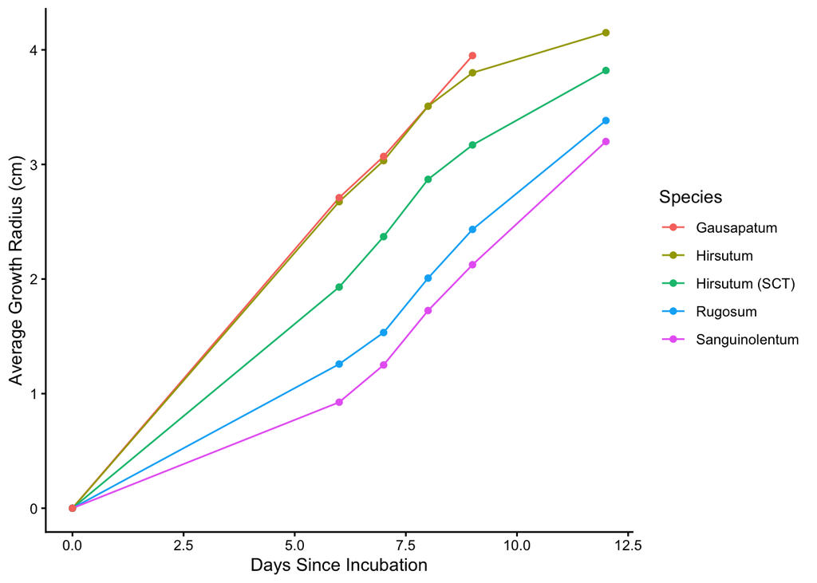

```r
ggplot(
  conspecific_data_clean,
  aes(
    x = Days_Since_Incubation,
    y = Average_Growth_Radius,
    group = Species,
    color = Species
  )
) +
  geom_line(na.rm = TRUE) +
  geom_point(na.rm = TRUE) +
  labs(
    x = "Days Since Incubation",
    y = "Average Growth Radius (cm)",
    color = "Species"
  ) +
  theme_classic()
```

## Graphs for Single Spore Isolate Variation

Average radial growth was calculated by measuring the radius at multiple points around the circumference of the growing mycelium at each time point. These measurements were averaged to obtain a single radial growth value for each isolate at each day of incubation. The mean growth values of the individual isolates were can be then be then compared across all isolates within each specimen group to illustrate rates different growth rates between siblings (progeny from same individual).

```r
isolate_data <- read_csv("Stereum Sampling Master Sheet  - Intraspecies Growth.csv")
```

#### Make Graph

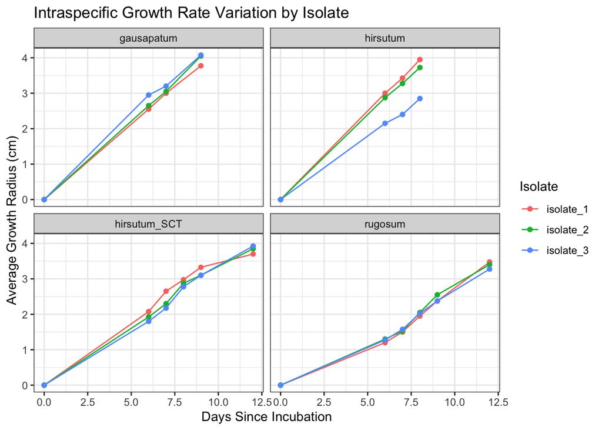

```r
#Day 0 isolates
day_0_isolates <- expand.grid(
  Specimen = c("hirsutum", "rugosum", "hirsutum_SCT", "gausapatum"),
  Isolate = c("isolate_1", "isolate_2", "isolate_3")
)
day_0_isolates$Average_Growth_Radius <- 0
day_0_isolates$Days_Since_Incubation <- 0

# Combine with data
isolate_combined <- rbind(day_0_isolates, isolate_data)

# Clean specimen names just in case
isolate_combined$Specimen <- trimws(isolate_combined$Specimen)

# Plot
ggplot(isolate_combined, aes(x = Days_Since_Incubation,
                             y = Average_Growth_Radius,
                             colour = Isolate,
                             group = Isolate)) +
  geom_line() +
  geom_point() +
  facet_wrap(~ Specimen) +
  labs(x = "Days Since Incubation",
       y = "Average Growth Radius (cm)",
       title = "Intraspecific Growth Rate Variation by Isolate") +
  theme_bw()
```